# Week 4 - Workshop 2: Exploring Nycflights - Solution

YOUR NAME

```r
library(tidyverse)
library(nycflights13)
```

# Section A

Look at the sample code and write down what it does

*Note: Make sure line 9 above has been run, or the flight data will not be found.*

This code bolew filters for the rows with the airport code ‘LGA’

```r
airports %>% filter(faa == "LGA")
```

```
## # A tibble: 1 x 8
##   faa   name         lat   lon   alt    tz dst   tzone
##   <chr> <chr>      <dbl> <dbl> <dbl> <dbl> <chr> <chr>
## 1 LGA   La Guardia  40.8 -73.9    22    -5 A     America/New_York
```

This code does the following:

- Step 1: Get flights with the Delta carrier ‘DL’, that started at the airport code ‘LGA’ in August
- Step 2: then join this with airports by the destination code
- Step 3: Create two new columns, with longitude and latitude

```r
delta <- flights %>%
  filter(carrier == "DL", origin == "LGA", month == 8) %>%
  left_join(airports, by = c("dest" = "faa")) %>%
  mutate(orig_lon = -73.9, orig_lat = 40.8)
```

The code below plots the delay in departure time relating to different wind direction (in degrees) for flights originating from ‘LGA’, where the wind speed was over 25mph.

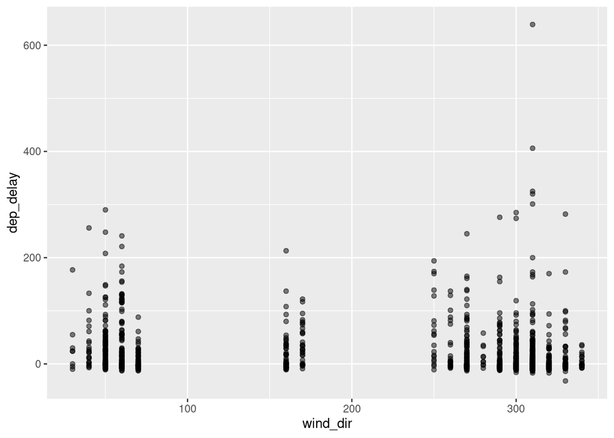

```r
flgt_weath <- flights %>%
  filter(origin == "LGA") %>%
  left_join(weather, by = c("origin", "time_hour")) %>%
  filter(wind_speed > 25)

ggplot(flgt_weath, aes(x = wind_dir, y = dep_delay)) +
   geom_point(alpha=0.5)
```

# Section B

Complete these exercises about the `nycflights13` data using wrangling operations, an appropriate join, and a plot. Use the examples from the “flight-movement.Rmd” file to provide guidance.

## Q1

Filter the flights data to contain just Delta flights (‘DL’), for August

```r
delta <- flights %>%
  filter(carrier == "DL", month == 8)
```

## Q2

Add the airport locations (lat, long) of the origin and destination to the flights data

Adding coordinates would be useful if you were asked to plot flights on a map, but we won’t do this today

```r
flights_latlon <- left_join(flights,
                                   airports,
                                   by = c("origin" = "faa")) %>%
  rename("origin_latitude" = "lat",
         "origin_longitude" = "lon")

flights_latlon <- left_join(flights_latlon,
                            airports,
                            by  = c("dest" = "faa")) %>%
  rename("dest_latitude" = "lat",
         "dest_longitude" = "lon")


# Or you could do this in one move, by piping the first join into the second:

flights_latlon <- left_join(flights,
                            airports,
                            by = c("origin" = "faa")
) %>%
  rename(
    "origin_latitude" = "lat",
    "origin_longitude" = "lon"
  ) %>%
  left_join(
    airports,
    by = c("dest" = "faa" )
  ) %>%
  rename(
    "dest_latitude" = "lat",
    "dest_longitude" = "lon"
  )
```

# Section C

Lets look at how cross winds affect airport operations.

## Q1

Join the weather data to the flights data

```r
flgt_weath <- flights %>%
  left_join(weather, by = c("origin", "time_hour"))
```

## Q2

Filter by origin airport ‘EWR’ and wind speeds higher than 20mph

```r
flgt_weath_ewr <- flgt_weath %>%
  filter(origin == "EWR", wind_speed > 20)
```

## Q3

Plot delay against wind direction

Does wind direction, when windspeed is stronger, affect the operations at the airport?

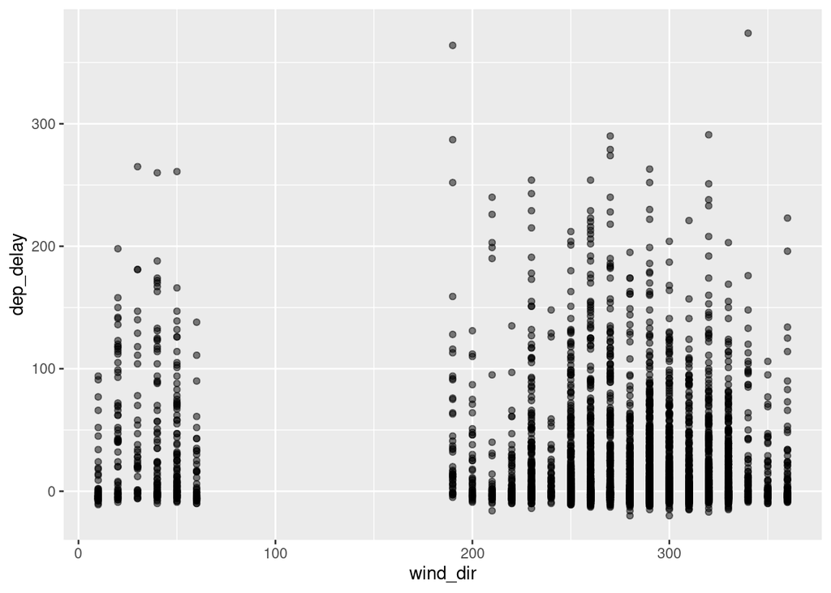

```r
ggplot(flgt_weath_ewr,
       aes(x = wind_dir,
           y = dep_delay)) +
   geom_point(alpha=0.5)
```

If the wind is reasonably strong, and perhaps if it is blowing across the runway there may be more delays.